# Time Series Analysis of Ozone Layer Thickness

## 6.4 Differencing

```r
ozone_diff <- diff(ozone, differences = 1)
```

Since both the Box-Cox and Logaritham transformation was unable to transform the ozone time series into a stationary series nor improve the normality of the series, differencing will be applied.

### 6.4a Plot of the first differencing

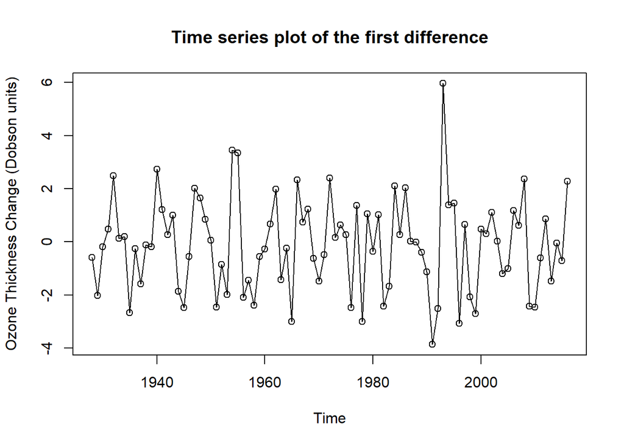

```r
plot(ozone_diff,type='o',ylab='Ozone Thickness Change (Dobson units)', main ="Time series plot of the first difference")
```

The results from the first differencing looks promising as there is little evidence for obvious trend.

### 6.4b Q-Q Plot

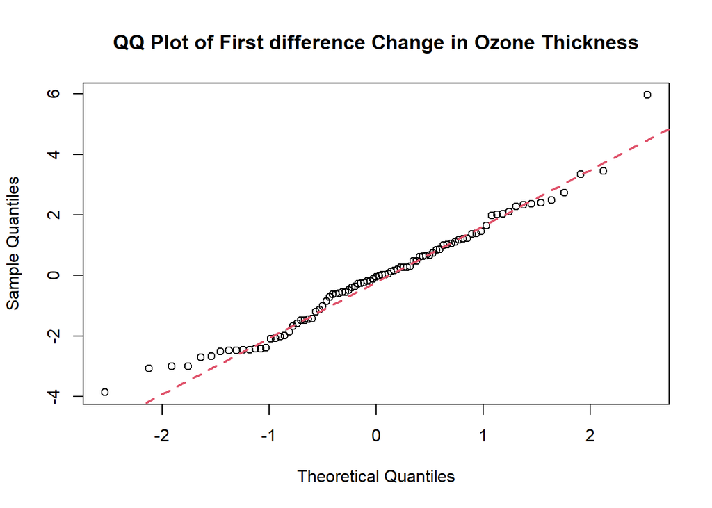

```r
qqnorm(ozone_diff, main="QQ Plot of First difference Change in Ozone Thickness")
qqline(ozone_diff, col=2, lty=2, lwd=2)
```

### 6.4c Dickey-Fuller Unit Root test

```r
adf.test(ozone_diff)
```

```
##
##  Augmented Dickey-Fuller Test
##
## data:  ozone_diff
## Dickey-Fuller = -7.1568, Lag order = 4, p-value = 0.01
## alternative hypothesis: stationary
```

The p-value is 0.01 and the null hypothesis of non-stationarity is rejected. Therefore it can be concluded that the first differencing make the series stationary.

### 6.4d ACF and PACF of first differencing

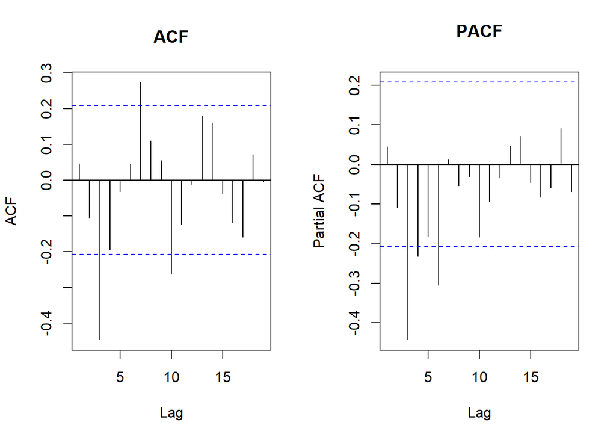

```r
par(mfrow=c(1,2))
acf(ozone_diff, main='ACF')
pacf(ozone_diff, main='PACF')
```

## 6.5 Dickey-Fuller Unit Root Test

```r
adf.test(ozone_diff, alternative = c("stationary", "explosive"), k = trunc((length(ozone_diff)-1)^(1/3)))
```

```
##
##  Augmented Dickey-Fuller Test
##
## data:  ozone_diff
## Dickey-Fuller = -7.1568, Lag order = 4, p-value = 0.01
## alternative hypothesis: stationary
```

The p value of 0.01 is less than 0.05 significance level and the null hypothesis is rejected. The conclusiong can be made that after the first differencing, the ozone time series is indeed stationary.

## 6.6 Extended Autocorrelation Function (EACF)

```r
eacf(ozone_diff)
```

```
## AR/MA
##   0 1 2 3 4 5 6 7 8 9 10 11 12 13
## 0 o o x o o o x o o x o  o  o  o
## 1 x o x o o o o o o x o  o  o  o
## 2 x o x o o o x o o x o  o  o  o
## 3 x o x o o x o o o o o  o  o  o
## 4 x o o x o x o o o o o  o  o  o
## 5 x x x x o x o o o o o  o  o  o
## 6 o o o x x o o o o o o  o  o  o
## 7 o o o x o o o o o o o  o  o  o
```

The top left vertex without any “x” starts from p=0 and q=3. The set of possible ARIMA model are as follows : ARIMA(0,1,3), ARIMA(1,1,3), ARIMA(0,1,4), ARIMA(1,1,4).

## 6.7 Bayesian Information Criterion (BIC)

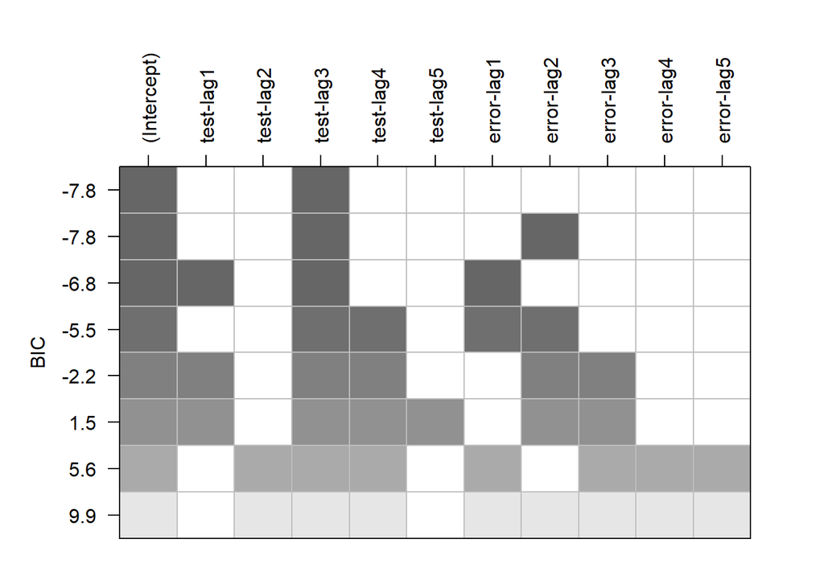

```r
res = armasubsets(ozone_diff, nar=5, nma=5, y.name='test', ar.method='ols')
plot(res)
```

## 6.8 Results

The final set of modeL indicates there are 10 possible candidates are ARIMA(1,1,1), ARIMA(2,1,1), ARIMA(3,1,1), ARIMA(0,1,3), ARIMA(1,1,3), ARIMA(0,1,4), ARIMA(1,1,4), ARIMA(3,1,0), ARIMA(3,1,2), ARIMA(1,1,2).

# 7. Conclusion

- The ozone time series first analyzed and is determined that the series is a non-stationary with downward trend, showing some evidence of seasonality, changing variation, and no intervention point.
- Linear,quadratic,seasonal, ombined seasonal & quadratic, and cosine models were used to fit the observation and analyse the residuals through histogram, QQ plots and shapiro test. There is evidence that the quadratic model shows more promising signs of a better fit through a high adjusted R-squared, most statistically significant coefficients, and a higher p-value for normality test.
- Next, the quadratic model is used to predict the annual ozone thickness changes for the next five years.
- Lastly, a proposed set of possible ARIMA(p, d, q) models using model specification tool such as ACF, PACF, EACF, BIC table are provided.

# 8. Appendices and References

1. Dr. Haydar Demirhan, retrieved from https://rmit.instructure.com/courses/67182/files/10178251?module_item_id=2056196, source:Time Series Analysis with R
2. Rob J Hyndman and George Athanasopoulos retrieved from https://otexts.com/fpp2/index.html, source: Forecasting: Principles and Practice